# Spatial Data Analysis in Python and R

## Overview

Areal data consists of a finite set of regions with well-defined boundaries. Geographic information systems (GIS) encode areal boundaries as a set of bounding polygons. To represent other features, e.g. area name and demographic together with GIS data we use packages which extend tabular dataframes to GIS data

- Python: [`GeoPandas`](https://geopandas.org/en/stable/index.html) - add support for geographic data to pandas objects.
- R: [`sf`](https://r-spatial.github.io/sf/) Simple Features for R - “spatial analysis simplified”

#### Region outlines - prefer low-resolution

Computing all neighbors for a map with many regions is computationally expensive; all polygons making up one region must be checked against all polygons of other regions for overlapping, shared, or very close boundaries or points. For this reason it is advisable to work with maps with a very coarse resolution as each area is described by fewer polygons, thus requiring less compute.

#### Neighbor graphs

By defining a neighbor relationship between area regions, we take the information from a GIS dataframe and convert it to a graph, where the areas are the nodes and edges denote the neighbor relationship. To compute neighbor graphs we use the following packages

- Python: [`libpysal`](https://pysal.org/libpysal/) the Python Spatial Analysis Library Core
- R: [`spdep`](https://r-spatial.r-universe.dev/spdep) Spatial Dependence: Weighting Schemes, Statistics

There are many ways to define contiguity, of these two straightforward metrics are *Rook* and *Queen* - regions which share bounding line are neighbors, and regions which share a bounding line or vertex are neighbors, respectively. The first sections this notebook show how to create, plot, and analyze spatial dataframes and neighbor graphs.

#### When geographic boundaries and conceptual boundaries don’t line up

Sometimes the contiguity graph doesn’t line up with the conceptual neighbor graph imposed according to some organizational schema. For example, the map may be drawn such that although a river separates one region from another, if the map is drawn such that they share a border somewhere at the bottom of the river. However if the river effectively prevents contact between inhabitants of the two regions, then for some analysis, they should not be considered neighbors and the graph must be modified accordingly. The later sections of this notebook show you how to do this.

## Example Dataset: NYC traffic accidents, localized to US Census blocks

The dataset we’re using is that used in the analysis published in 2019 [Bayesian Hierarchical Spatial Models: Implementing the Besag York Mollié Model in Stan](https://www.sciencedirect.com/science/article/pii/S1877584518301175).

The data consists of motor vehicle collisions in New York City, as recorded by the NYC Department of Transportation, between the years 2005-2014, restricted to collisions involving school age children 5-18 years of age as pedestrians.

Each crash was localized to the US Census tract in which it occurred, using boundaries from the 2010 United States Census, using the [2010 Census block map for New York City](https://data.cityofnewyork.us/City-Government/2010-Census-Blocks/v2h8-6mxf) The US Census tract is the lowest level of Census data resolution. A tract contains between 2,500 and 8,000 residents and boundaries that follow visible features. According to the [Census Bureau](https://www2.census.gov/geo/pdfs/reference/GARM/Ch10GARM.pdf)

> When first established, census tracts are to be as homogeneous as possible with respect to population characteristics, economic status, and living condition

### Measurements

> We obtained motor vehicle collision data from the New York City Department of Transportation for the ten most recent years of data available at the time of request (2005-2014). Within this dataset, we identified collisions involving school age children 5-18 years of age as pedestrians. We then assigned each crash to the census tract in which it occurred, using boundaries from the 2010 United States Census.

> We obtained 2010 US Census counts of youths aged 5-18 in each census tract from the US Census Bureau [@us-census] We also obtained the Census Bureau’s American Community Survey (ACS) five-year estimates of median household income and the percentage of commuters who traveled to work by means other than a private vehicle (i.e., by walking, bicycling, or using public transportation) for each tract for 2010-2014. We constructed an index of social fragmentation based on the work of Peter Congdon, using updated ACS estimates of vacant housing units, householders living alone, non-owner occupied housing units, and population having moved within the previous year. We standardized each of these metrics with a mean of zero and added them together as a single index. Finally, we obtained street level annual average daily traffic (AADT) data from the New York State Department of Transportation on the New York Open Data portal. We created a spatial overlay of streets and census tracts to assign each census tract the maximum AADT value of its underlying streets in 2015.

| Measures | Median | Min | Mean | Max |
| --- | --- | --- | --- | --- |
| Youth pedestrian injuries, 2005-14 | 6 | 0 | 8.2 | 57 |
| Population ages 5-18 years, 2010 | 510 | 6 | 596.4 | 3,315 |
| Med. household income in USD, 2010-14 | $53,890 | $9,327 | $58,497 | $232,266 |
| Pct. commute by walk/cycle/public trans, 2010-14 | 73.9 | 9.7 | 69.8 | 100.0 |
| Standardized social fragmentation index | -0.1 | -6.7 | 0.0 | 18.7 |
| Traffic Volume (AADT), 2015 | 19,178 | 843 | 37,248 | 276,476 |

## Preliminary Data Analysis

### Spatial Data manipulation in R and Python

Geographic information systems (GIS) data is any item which has a geographic location, either a single point or a set of bounding polygons. Cartographic data (maps) are encoded as a set of records, one per map region. The [shapefile format](https://en.wikipedia.org/wiki/Shapefile) is an open specification used to insure interoperability among GIS software packages. When items in a dataset contain location labels, it is necessary to obtain a set of shapefiles for the corresponding map. To compute with GIS data, we need packages which can do the geographic math.

- In Python the [GeoPandas](https://geopandas.org/en/stable/) package extends the datatypes used by pandas to allow spatial operations on geometric types, and the [`libpysal`](https://pysal.org/libpysal/) package analyzes spatial relationships between locations.
- In R the equivalent operations are provided by the [`sf`](https://r-spatial.github.io/sf/) and the [`spdep`](https://r-spatial.github.io/spdep/) package.

To visualize GIS data, we need to be able to draw maps and spatial graphs.

- In R, ggplot2 can produce beautiful maps for GIS data.
- The python equivalent of R’s `ggplot2` is [`plotnine`](https://plotnine.org/). We also use the [`splot`](https://pysal.org/notebooks/viz/splot/intro.html) package which provides additional plotting functions for spatial graph networks.

### Notebook Startup: Load Packages / Libraries

**Python**

```python
# import all libraries used in this notebook
import os
import numpy as np
import pandas as pd
import geopandas as gpd
import libpysal
import matplotlib as plt
import splot as splt
from splot.libpysal import plot_spatial_weights
import plotnine as p9

# suppress plotnine warnings
import warnings
warnings.filterwarnings('ignore')
# setup plotnine look and feel global
p9.theme_set(
  p9.theme_grey() +
  p9.theme(text=p9.element_text(size=10),
        plot_title=p9.element_text(size=14),
        axis_title_x=p9.element_text(size=12),
        axis_title_y=p9.element_text(size=12),
        axis_text_x=p9.element_text(size=8),
        axis_text_y=p9.element_text(size=8)
       )
)
# useful themes
xlabels_90 = p9.theme(axis_text_x = p9.element_text(angle=90, hjust=1))
map_theme =  p9.theme(figure_size=(6,5),
                 axis_text_x=p9.element_blank(),
                 axis_ticks_x=p9.element_blank(),
                 axis_text_y=p9.element_blank(),
                 axis_ticks_y=p9.element_blank())
```

**R**

```r
library(sf)
library(spdep) |> suppressPackageStartupMessages()
library(ggplot2)
library(tidyverse) |> suppressPackageStartupMessages()
```

### Load study data

The study data and GIS data have been assembled into a single GeoJSON file.

**Python**

```python
nyc_geodata = gpd.read_file(os.path.join('data', 'nyc_study.geojson'))
print(type(nyc_geodata))
```

```
<class 'geopandas.geodataframe.GeoDataFrame'>
```

```python
print(nyc_geodata.columns)
```

```
Index(['CTLabel', 'BoroCode', 'BoroName', 'CT2010', 'BoroCT2010', 'CDEligibil',
       'NTACode', 'NTAName', 'PUMA', 'Shape_Leng', 'Shape_Area', 'BoroFips',
       'ct2010full', 'kids_per_sq_mi', 'count', 'kid_pop', 'pct_pubtransit',
       'med_hh_inc', 'traffic', 'frag_index', 'geometry'],
      dtype='object')
```

```python
print(nyc_geodata['BoroName'].value_counts())
```

```
BoroName
Brooklyn         745
Queens           639
Bronx            329
Manhattan        274
Staten Island    108
Name: count, dtype: int64
```

**R**

```r
nyc_geodata = st_read(file.path("data", "nyc_study.geojson"))
class(nyc_geodata)
```

```
[1] "sf"         "data.frame"
```

```r
names(nyc_geodata)
```

```
 [1] "CTLabel"        "BoroCode"       "BoroName"       "CT2010"
 [5] "BoroCT2010"     "CDEligibil"     "NTACode"        "NTAName"
 [9] "PUMA"           "Shape_Leng"     "Shape_Area"     "BoroFips"
[13] "ct2010full"     "kids_per_sq_mi" "count"          "kid_pop"
[17] "pct_pubtransit" "med_hh_inc"     "traffic"        "frag_index"
[21] "geometry"
```

```r
table(nyc_geodata$BoroName)
```

```
        Bronx      Brooklyn     Manhattan        Queens Staten Island
          329           745           274           639           108
```

#### Traffic accidents - kids hit by cars

Plot the observed outcome `counts`.

*Note:* Count data is properly plotted as a bar chart, not histogram plus density, but the visualization is useful.

**Python**

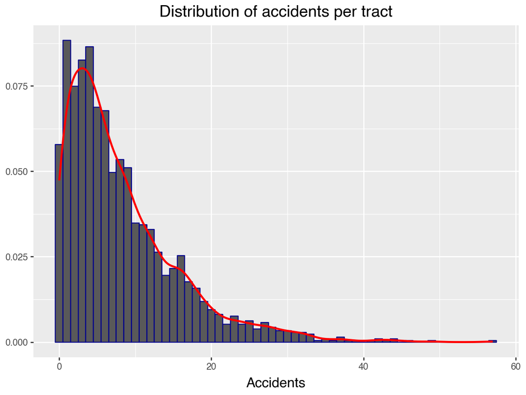

```python
p1 = (
    p9.ggplot(data=nyc_geodata, mapping=p9.aes(x='count')) +
    p9.geom_histogram(p9.aes(y=p9.after_stat('density')), bins=58, color='DarkBlue') +
    p9.geom_density(color="red", size=1) +
    p9.ggtitle("Distribution of accidents per tract") +
    p9.xlab("Accidents") + p9.ylab("")
)
p1.show()
```

**R**

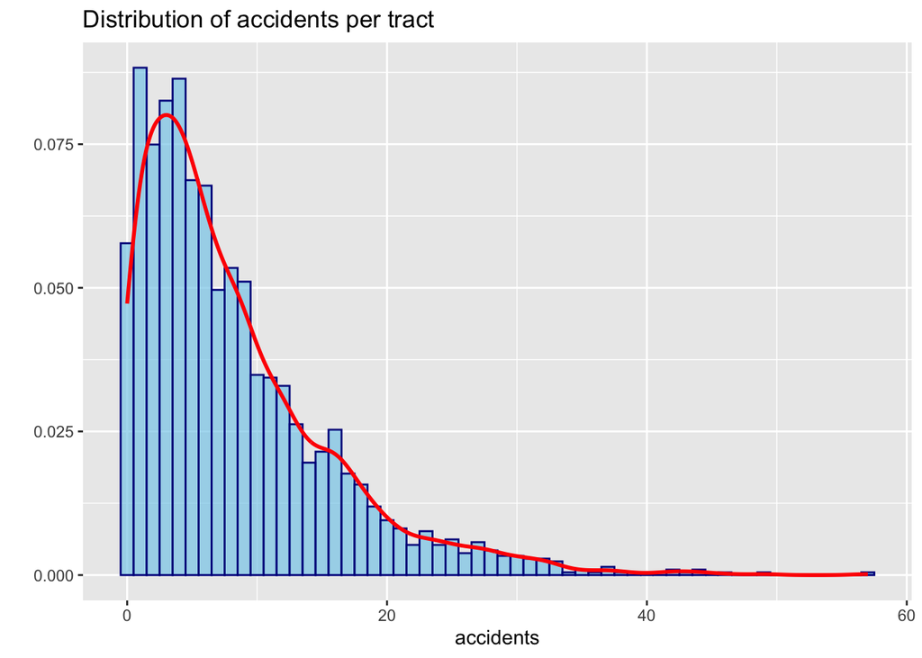

```r
ggplot(data = nyc_geodata, aes(x = count)) +
  geom_histogram(aes(y = after_stat(density)), bins = 58, color = 'DarkBlue', fill = "skyblue", alpha = 0.7) +
  geom_density(color = "red", linewidth = 1) +
  ggtitle("Distribution of accidents per tract") +
  xlab("accidents") +
  ylab("")
```

### Visualize by Map Areas

#### Show areal map, fill color is accidents per tract

**Python**

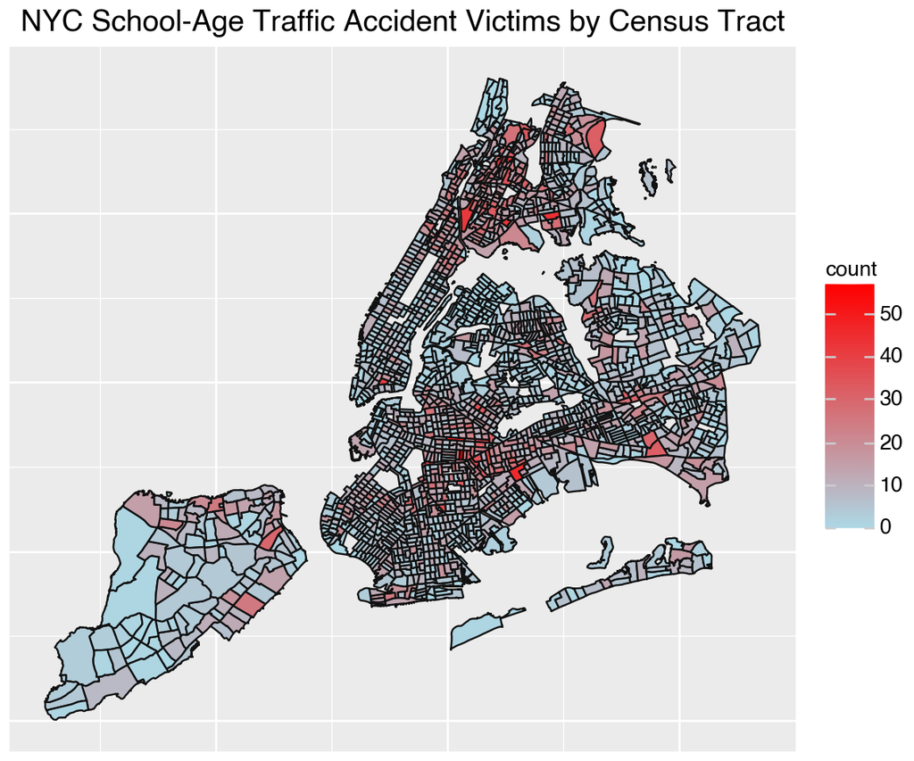

```python
p2 = (
    p9.ggplot(nyc_geodata) +
    p9.geom_map(p9.aes(fill='count')) +
    p9.scale_fill_gradient(low="lightblue", high="red") +
    p9.labs(title="NYC School-Age Traffic Accident Victims by Census Tract") +
    map_theme
)
p2.show()
```

**R**

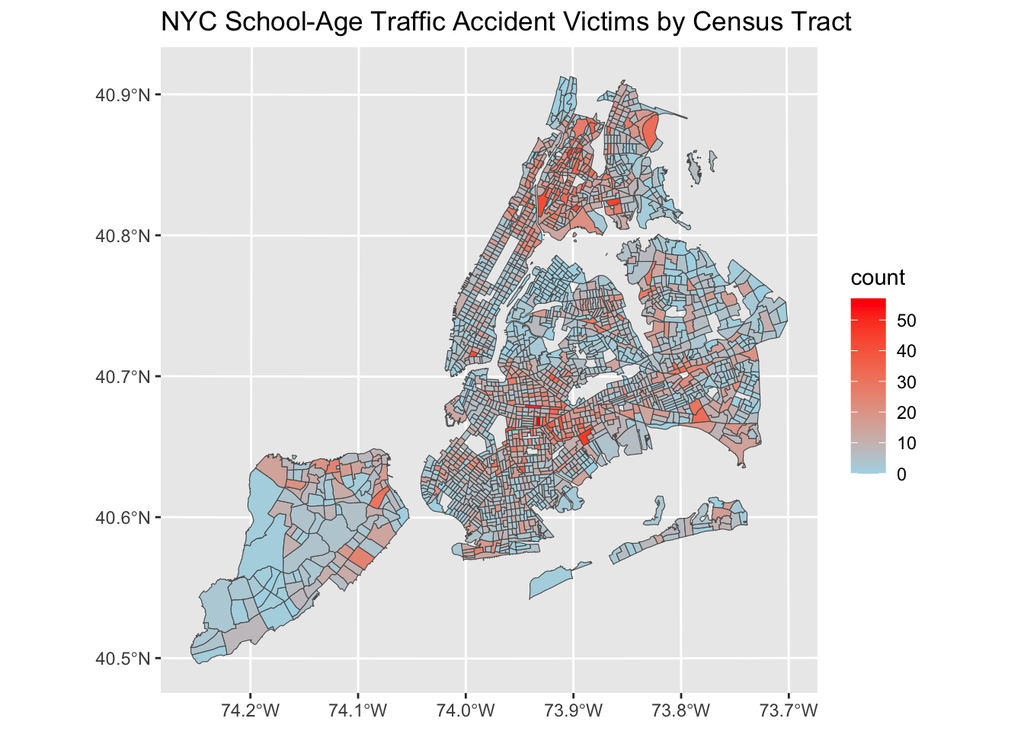

```r
ggplot(data = nyc_geodata) +
geom_sf(aes(fill = count)) +
scale_fill_gradient(low = "lightblue", high = "red") +
labs(title = "NYC School-Age Traffic Accident Victims by Census Tract")
```

#### Show areal map, fill color is kid population per tract

**Python**

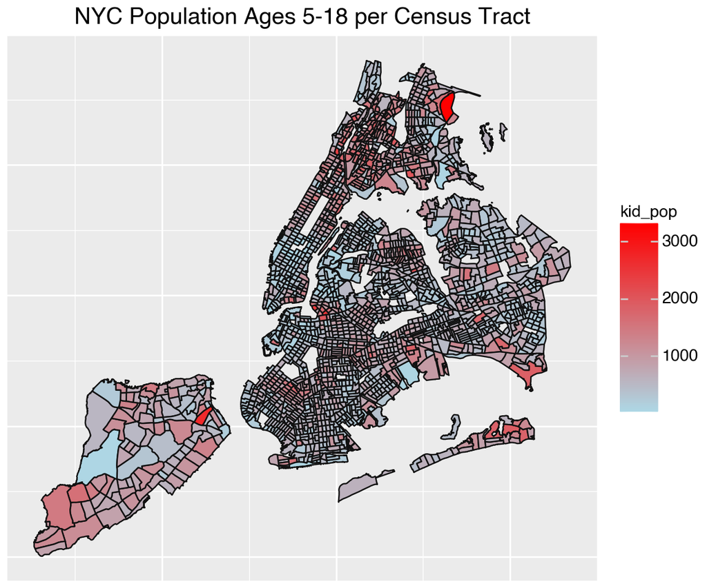

```python
p3 = (
    p9.ggplot(nyc_geodata) +
    p9.geom_map(p9.aes(fill='kid_pop')) +
    p9.scale_fill_gradient(low="lightblue", high="red") +
    p9.labs(title = "NYC Population Ages 5-18 per Census Tract") +
    map_theme
)
p3.show()
```

**R**

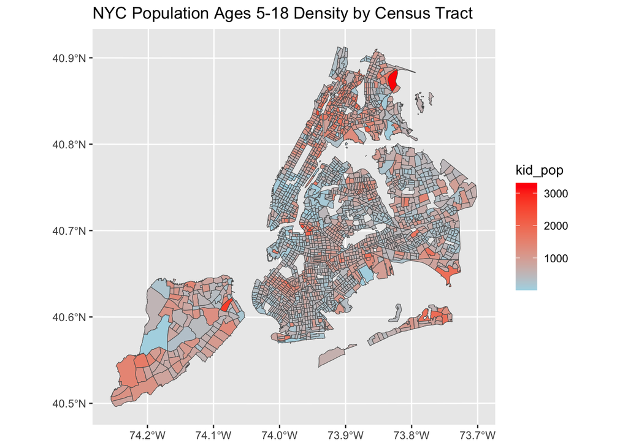

```r
ggplot(data = nyc_geodata) +
    geom_sf(aes(fill = kid_pop)) +
    scale_fill_gradient(low = "lightblue", high = "red") +
    labs(title = "NYC Population Ages 5-18 Density by Census Tract")
```

#### Population: raw counts, density per square mile

**Python**

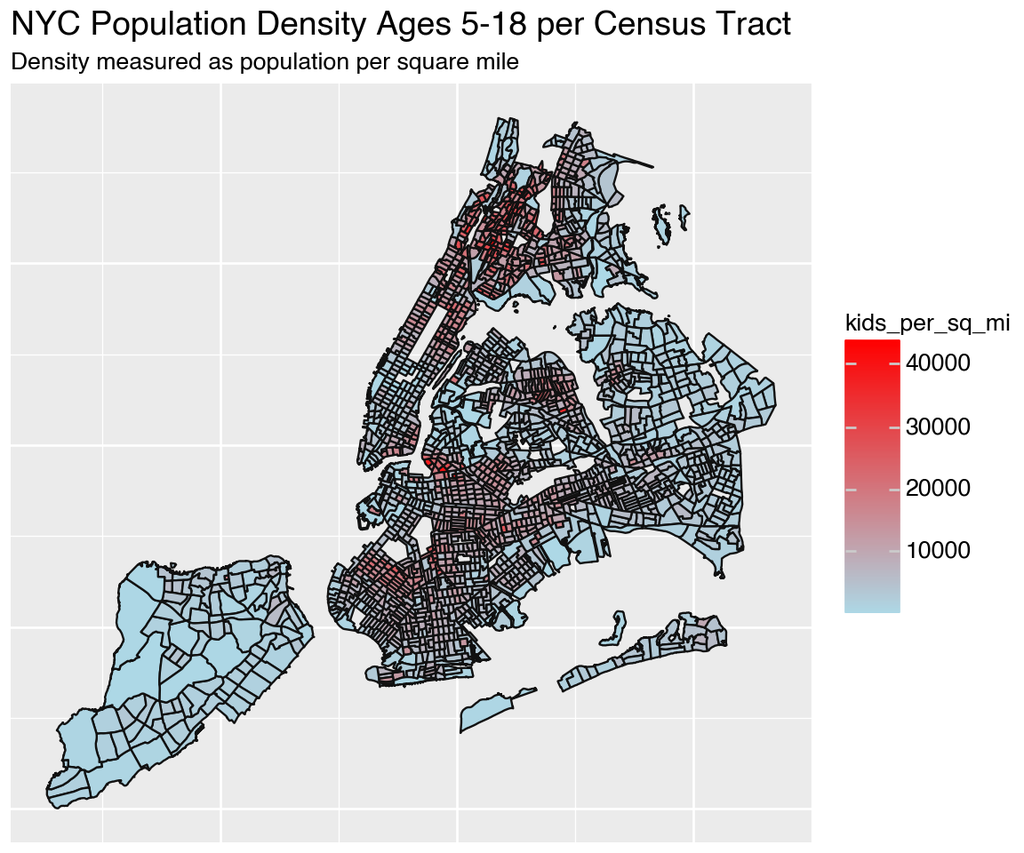

```python
p4 = (
    p9.ggplot(nyc_geodata) +
    p9.geom_map(p9.aes(fill='kids_per_sq_mi')) +
    p9.scale_fill_gradient(low="lightblue", high="red") +
    p9.labs(title = "NYC Population Density Ages 5-18 per Census Tract",
         subtitle = "Density measured as population per square mile") +
    map_theme
)
p4.show()
```

**R**

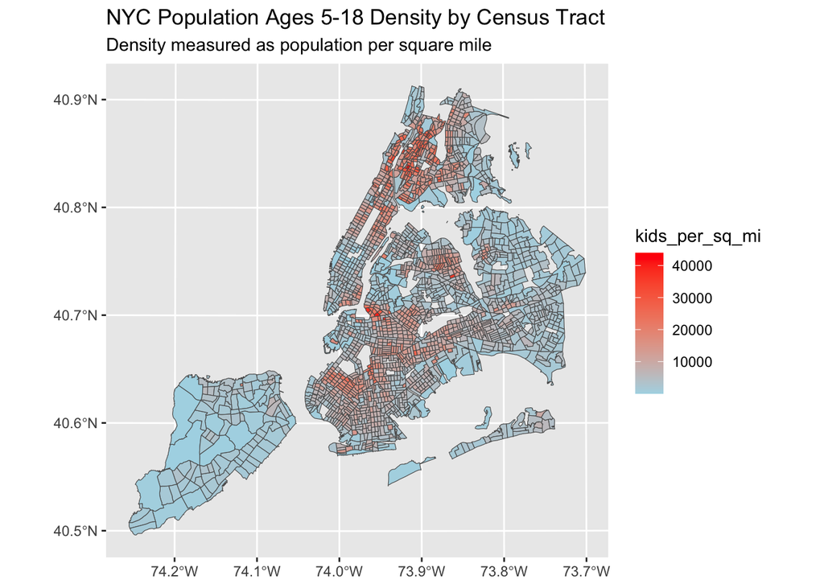

```r
ggplot(data = nyc_geodata) +
    geom_sf(aes(fill = kids_per_sq_mi)) +
    scale_fill_gradient(low = "lightblue", high = "red") +
    labs(title = "NYC Population Ages 5-18 Density by Census Tract",
         subtitle = "Density measured as population per square mile")
```

### Exercises

- Visualize `med_hh_inc` (median household income), `frag_index` (fragmentation index), and `traffic`.

## From spatial dataframes to graphs

The neighbor graph is constructed from a geodataframe by analysis of the bounding polygons in the `geometry` column. Both libpysal and spdep provide functions to visualize neighbor graph overlaid on the map. The neighbor graph objects merely index entries in the geodataframe. Therefore plotting requires extracting the centroids of each regions from the geodataframe in order to align the graph to the map. Because the default indexing scheme is row index, it is critical that the dataframe and the neighbor graph remain in sync; reordering or otherwise modifying the geodataframe will completely scramble the graph and the resulting plot will look nothing like a proper network.

**Python**

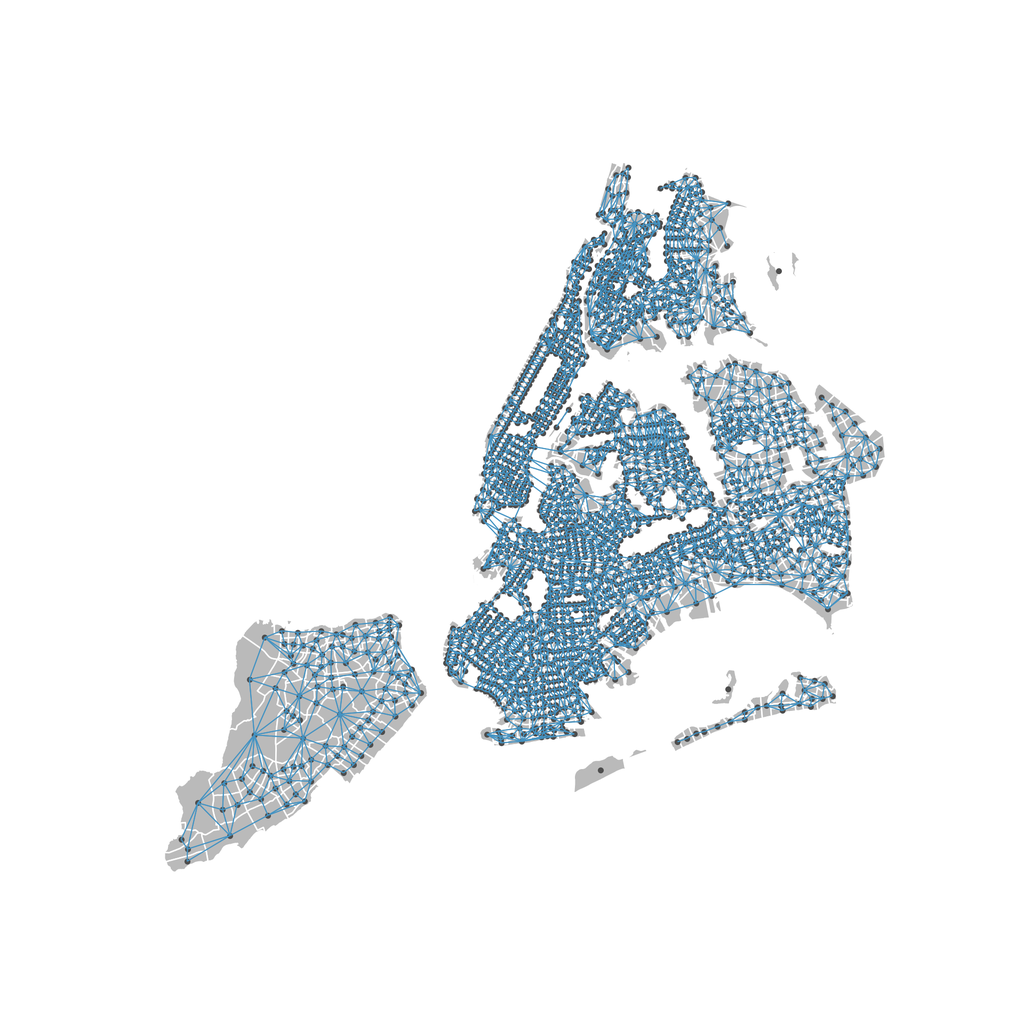

```python
nyc_nbs = libpysal.weights.Rook.from_dataframe(nyc_geodata, geom_col='geometry')
plot_spatial_weights(nyc_nbs, nyc_geodata)
```

**R**

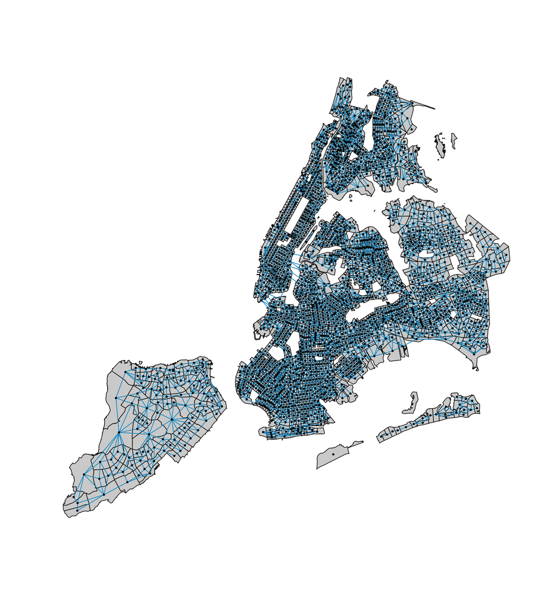

```r
nyc_nbs = poly2nb(nyc_geodata, queen=FALSE)
nyc_coords = st_coordinates(st_centroid(nyc_geodata['geometry']))
plot(st_geometry(nyc_geodata), col='lightgrey')
plot(nyc_nbs, coords=nyc_coords, col='deepskyblue3', add=TRUE, pch=20, cex=0.6)
```

The per-node sets of neighbors are the same. To see this, we examine the set of neighbors for the first 3 nodes in the graph.

*Python*

```python
print('neighbors', list(nyc_nbs.neighbors.items())[:3])
print('cardinalities', list(nyc_nbs.cardinalities.values())[:3])
```

```
neighbors [(0, [1, 2, 4]), (1, [0, 2, 51, 56, 44]), (2, [0, 1, 18, 4, 14, 60, 44])]
cardinalities [3, 5, 7]
```

*R*

```r
cat('neighbors: [', unlist(nyc_nbs[1]), '], ')
cat('[', unlist(nyc_nbs[2]), '], ')
cat('[', unlist(nyc_nbs[3]), ']\n')
cards = card(nyc_nbs)[1:3]
cat('cardinalities: ', cards[1], cards[2], cards[3], '\n', sep=" ")
```

```
neighbors: [ 2 3 5 ], [ 1 3 45 52 57 ], [ 1 2 5 15 19 45 61 ]
cardinalities:  3 5 7
```

We note two differences:

- Python indexes from $0$ while R indexes from $1$[^1]
- The R list is sorted, ascending, the Python list is unsorted.

### Connected and Disconnected Graphs: Components and Islands

A graph component is a set of nodes for which there is a path from any node in the component to every other node in that set. A fully connected graph is a graph over a single component. As the map of NYC shows (above), the graph is not fully connected, i.e., it is impossible to find a path from Staten Island to the Bronx, and there are 3 regions which have no neighbors - these are islands, (also called singleton nodes).

The `libpysal` and `spdep` APIs both provide a series of methods and attributes for computing properties of the neighbor graph.

**Python**

```python
print(f'max number of neighbors per node: {nyc_nbs.max_neighbors}')
print(f'mean number of neighbors per node: {nyc_nbs.mean_neighbors}')
print(f'islands? {nyc_nbs.islands}')
print(f'number of components: {nyc_nbs.n_components}')
unique, counts = np.unique(nyc_nbs.component_labels, return_counts=True)
print('nodes per component')
for u, c in zip(unique, counts):
    print(f'component {u}: {c}')
```

```
max number of neighbors per node: 12
mean number of neighbors per node: 4.926968973747017
islands? [328, 1860, 1903]
number of components: 8
nodes per component
component 0: 329
component 1: 1
component 2: 1631
component 3: 2
component 4: 1
component 5: 22
component 6: 1
component 7: 108
```

**R**

```r
summary(nyc_nbs)
cat('nodes per component')
table(n.comp.nb(nyc_nbs)$comp.id)
```

```
Neighbour list object:
Number of regions: 2095
Number of nonzero links: 10328
Percentage nonzero weights: 0.2353142
Average number of links: 4.929833
3 regions with no links:
329 1861 1904
8 disjoint connected subgraphs
Link number distribution:

  0   1   2   3   4   5   6   7   8   9  10  11  12
  3   7  33 217 553 655 398 149  56  10   8   4   2
7 least connected regions:
214 319 1311 1312 1329 1863 1974 with 1 link
2 most connected regions:
1023 1621 with 12 links
nodes per component
   1    2    3    4    5    6    7    8
 329    1 1631    2    1   22    1  108
```

### Rook vs Queen - does it make a difference?

Consider the non-edge squares on a chessboard. By the Rook metric each square has 4 neighbors and by the Queen metric, each square has 8 neighbors. How does this play out when the map is not as regular as a chessboard?

**Python**

```python
nyc_nbs_queen = libpysal.weights.Queen.from_dataframe(nyc_geodata, geom_col='geometry')
print(f'queen max number of neighbors per node: {nyc_nbs_queen.max_neighbors}')
print(f'rook max number of neighbors per node: {nyc_nbs.max_neighbors}')
print(f'queen mean number of neighbors per node: {nyc_nbs_queen.mean_neighbors}')
print(f'rook mean number of neighbors per node: {nyc_nbs.mean_neighbors}')
print(f'queen islands? {nyc_nbs_queen.islands}')
print(f'rook islands? {nyc_nbs.islands}')
print(f'queen number of components: {nyc_nbs_queen.n_components}')
print(f'rook number of components: {nyc_nbs.n_components}')
```

```
queen max number of neighbors per node: 14
rook max number of neighbors per node: 12
queen mean number of neighbors per node: 5.891169451073986
rook mean number of neighbors per node: 4.926968973747017
queen islands? [328, 1860, 1903]
rook islands? [328, 1860, 1903]
queen number of components: 8
rook number of components: 8
```

**R**

```r
nyc_nbs_queen = poly2nb(nyc_geodata, queen=TRUE)
cat("*** Queen metric nb summary ***\n\n")
summary(nyc_nbs_queen)
cat("\n\n*** Rook metric nb summary ***\n\n")
summary(nyc_nbs)
```

```
*** Queen metric nb summary ***

Neighbour list object:
Number of regions: 2095
Number of nonzero links: 12342
Percentage nonzero weights: 0.2812014
Average number of links: 5.891169
3 regions with no links:
329 1861 1904
8 disjoint connected subgraphs
Link number distribution:

  0   1   2   3   4   5   6   7   8   9  10  11  12  13  14
  3   5  24  92 268 463 531 395 211  69  18   9   5   1   1
5 least connected regions:
319 1311 1312 1863 1974 with 1 link
1 most connected region:
1621 with 14 links


*** Rook metric nb summary ***

Neighbour list object:
Number of regions: 2095
Number of nonzero links: 10328
Percentage nonzero weights: 0.2353142
Average number of links: 4.929833
3 regions with no links:
329 1861 1904
8 disjoint connected subgraphs
Link number distribution:

  0   1   2   3   4   5   6   7   8   9  10  11  12
  3   7  33 217 553 655 398 149  56  10   8   4   2
7 least connected regions:
214 319 1311 1312 1329 1863 1974 with 1 link
2 most connected regions:
1023 1621 with 12 links
```

## Editing Neighbor Graph Objects

Oftentimes the geospatial structure obtained from the map boundaries may conflict with the logical spatial structure. Two regions may be map-wise adjacent but if the boundary between them is a river or road which prevents contact or mixing between the two regions, then they might not be considered “neighbors”. The converse is also problematic: the geo-coordinates of two regions may not share a bounding line or point but should be considered adjacent for the purposes of the analysis.

The NYC neighbor graph is problematic in both of these two ways. The first problem - map-wise adjacent but not logically adjacent - is that there are multiple edges between Manhattan, on one side of the East River, and Brooklyn, and Queens, on the other side. Perhaps this is due to administrative boundaries to account for bridges, tunnels, and subways, or else it could simply be a map artifact. For the analysis of pedestrian traffic, these regions should not be connected. The second problem arises if we want to use a single ICAR component to account for spatial variance which requires a fully connected neighbor graph.

To modify the graph so that it reflects the desired logical structure requires editing the libpysal `W` and spdep `nb` objects and to do this it is necessary to understand their respective APIs.

### The libpysal `W` object API

This object contains 3 member dictionaries, plus several attributes. The key member variables are:

- `W.neighbors`: A dict mapping each region ID to a list of neighboring region IDs.
- `W.weights`: A dict mapping each region ID to a list of corresponding weights (aligned with neighbors). These quantify the strength of the relationship (often adjacency or proximity) between different geographic areas. Because the Rook metric computes a simple binary relationship, the value of all weights is $1.0$.
- `W.cardinalities`: A dict mapping each region ID to its number of neighbors.

If weights object is created without specifying the region IDS, as we did above:

```python
nyc_nbs = libpysal.weights.Rook.from_dataframe(nyc_geodata, geom_col='geometry')
```

the positional row indices of the geodataframe are used as ids.

```python
print('neighbors', list(nyc_nbs.neighbors.items())[:3])
print('cardinalities', list(nyc_nbs.cardinalities.values())[:3])
```

```
neighbors [(0, [1, 2, 4]), (1, [0, 2, 51, 56, 44]), (2, [0, 1, 18, 4, 14, 60, 44])]
cardinalities [3, 5, 7]
```

Although the `neighbors`, `weights` and `cardinalities` dictionaries are mutable, the attribute `n_components` is computed on object instantiation, therefore after any edits to the `neighbors` and `weights` dicts, it is necessary to instantiate a new object using the edited `neighbors` and `weights` dictionaries. The `cardinalities` list will be recomputed, along with `n_components` and `component_labels`.

### The spdep `nb` object API

The `nb` object only stores adjacency information; a separate `listw` object (e.g., `spdep::nb2listw(nb, style = "W")`) pairs an `nb` object with weights. The key components are:

- `nb[[i]]`: A vector of integer indices for the neighbors of region *i*.
- `attr(nb, "region.id")`: Character vector of unique IDs for each region.
- `attr(nb, "sym")`: Logical indicating whether the neighbors list is symmetric (optional).

```r
cat('neighbors: [', unlist(nyc_nbs[1]), '], ')
cat('[', unlist(nyc_nbs[2]), '], ')
cat('[', unlist(nyc_nbs[3]), ']\n')
cards = card(nyc_nbs)[1:3]
cat('cardinalities: ', cards[1], cards[2], cards[3], '\n', sep=" ")
```

```
neighbors: [ 2 3 5 ], [ 1 3 45 52 57 ], [ 1 2 5 15 19 45 61 ]
cardinalities:  3 5 7
```

The `nb` object region ids always correspond to their row index in the geodataframe.

```r
ids = attr(nyc_nbs, "region.id")[1:3]
cat('region ids: ', ids[1], ids[2], ids[3], '\n', sep=" ")
cat('is symmetric? ')
attr(nyc_nbs, "sym")
```

```
region ids:  1 2 3
is symmetric? [1] TRUE
```

### Checking your work

After editing a neighbor graph object, it is necessary to check that the edited object is both consistent and contains only valid node ids. At a minimum, you should check that

- the graph is symmetric
- there are no duplicate neighbors
- the weights are valid
- plot the modified graph to verify the edits

For a python libpysal `W` object `w` with corresponding GeoDataFrame `gdf`

**Python**

```python
# is the graph symmetric?
print(f'is symmetric? {len(w.asymmetries) == 0}')

# is the graph fully connected?
print(f'number of components: {nyc_nbs.n_components}')

# what is the component structure?
unique, counts = np.unique(nyc_nbs.component_labels, return_counts=True)
print('nodes per component')
for u, c in zip(unique, counts):
    print(f'component {u}: {c}')

# plot for visual inspection
plot_weights(w, gdf.geometry)
plt.show()
```

For a R spdep `nb` object `nb_obj`

**R**

```r
cat('is symmetric? ', is.symmetric.nb(nb_obj), '\n')

# is the graph fully connected?
summary(nb_obj)

# what is the component structure?
cat('nodes per component')
table(n.comp.nb(nb_obj)$comp.id)

# plot for visual inspection
gdf_coords = st_coordinates(st_centroid(gdf['geometry']))
plot(st_geometry(gdf), col='lightgrey')   # colors chosen to match libpysal defaults
plot(nb_obj, coords=gdf_coords, col='deepskyblue3', add=TRUE, pch=20, cex=0.6)
```

## Deleting edges from the neighbor graph

To delete an edge between nodes `i` and `j` in the libpysal `W` object requires updating the `neighbors` and `weights` entries for both `i` and `j` as well as decrementing the cardinality of each. If this edit disconnects the graph or subgraph, it is necessary to instantiate a new `W` object from the `neighbors` and `weights` list in order to recompute the `n_components` and `component_labels` attributes.

**Python**

```python
def delete_symmetric_edge(w, i, j):
    """
    Remove the neighbor relationship between i and j in a libpysal.weights.W object.
    Parameters:
    - w: libpysal.weights.W object
    - i: int or str, node identifier
    - j: int or str, node identifier
    """
    # If j is in i's neighbor list, remove it (and corresponding weight)
    if j in w.neighbors[i]:
        idx = w.neighbors[i].index(j)
        w.neighbors[i].pop(idx)
        w.weights[i].pop(idx)
        w.cardinalities[i] = len(w.neighbors[i])

    # If i is in j's neighbor list, remove it (and corresponding weight)
    if i in w.neighbors[j]:
        idx = w.neighbors[j].index(i)
        w.neighbors[j].pop(idx)
        w.weights[j].pop(idx)
        w.cardinalities[j] = len(w.neighbors[j])
```

In R, simply update `nb` object’s `neighbors` list.

**R**

```r
remove_symmetric_edge_nb <- function(nb, i, j) {
    nb[[i]] <- setdiff(nb[[i]], j)
    nb[[j]] <- setdiff(nb[[j]], i)
    return(nb)
}
```

### Example: Manhattan as an island

Instead of targeting the spurious connections directly via the node indices, we instead use the `BoroName` column of the `nyc_geodata` geodataframe to get per-borough lists of node ids and use them to identify which edges to drop from the graph.

The geodataframe `nyc_geodata` contains column `BoroName`. We use this to get the list of row indices for each of the boroughs Manhattan, Brooklyn, and Queens.

** Python **

```python
manhattan_indices = nyc_geodata[nyc_geodata['BoroName'] == 'Manhattan'].index
brooklyn_indices = nyc_geodata[nyc_geodata['BoroName'] == 'Brooklyn'].index
queens_indices = nyc_geodata[nyc_geodata['BoroName'] == 'Queens'].index
brooklyn_and_queens = brooklyn_indices.append(queens_indices)

print('Manhattan census tracts: ', len(manhattan_indices))
print('Brooklyn and Queens census tracts: ', len(brooklyn_and_queens))
```

```
Manhattan census tracts:  274
Brooklyn and Queens census tracts:  1384
```

** R **

```r
manhattan_indices <- which(nyc_geodata$BoroName == "Manhattan")
brooklyn_indices <- which(nyc_geodata$BoroName == "Brooklyn")
queens_indices <- which(nyc_geodata$BoroName == "Queens")
brooklyn_and_queens = c(brooklyn_indices, queens_indices)

cat('Manhattan census tracts: ', length(manhattan_indices))
cat('Brooklyn and Queens census tracts: ', length(brooklyn_and_queens))
```

```
Manhattan census tracts:  274Brooklyn and Queens census tracts:  1384
```

** Python **

```python
def clean_nbs_symmetric(w, target_indices, remove_indices):
    """
    Efficiently edit a neighbor graph by removing specified edges symmetrically.
    Parameters:
    - w: libpysal.weights.W object
    - target_indices: list of node identifiers
    - remove_indices: list of node identifiers
    """
    remove_set = set(remove_indices)  # Convert to set for O(1) lookups
    for node in target_indices:
        original_neighbors = w.neighbors[node]
        original_weights = w.weights[node]

        # Filter out neighbors to remove
        mask = [neighbor not in remove_set for neighbor in original_neighbors]
        w.neighbors[node] = [neighbor for neighbor, keep in zip(original_neighbors, mask) if keep]
        w.weights[node] = [weight for weight, keep in zip(original_weights, mask) if keep]
        w.cardinalities[node] = len(w.neighbors[node])

        # Remove the target node from each of the removed neighbors
        neighbors_to_remove = remove_set.intersection(original_neighbors)
        for neighbor in neighbors_to_remove:
            if node in w.neighbors[neighbor]:
                idx = w.neighbors[neighbor].index(node)
                w.neighbors[neighbor].pop(idx)
                w.weights[neighbor].pop(idx)
                w.cardinalities[neighbor] = len(w.neighbors[neighbor])
```

** R **

```r
clean_nbs_symmetric <- function(nb_obj, target_indices, remove_indices) {
  remove_set <- unique(remove_indices)
  for (node in target_indices) {
    original_neighbors <- nb_obj[[node]]
    neighbors_to_remove <- intersect(original_neighbors, remove_set)
    if (length(neighbors_to_remove) > 0) {
      nb_obj[[node]] <- setdiff(original_neighbors, neighbors_to_remove)

      for (neighbor in neighbors_to_remove) {
        neighbor_neighbors <- nb_obj[[neighbor]]
        nb_obj[[neighbor]] <- setdiff(neighbor_neighbors, node)
      }
    }
  }
  return(nb_obj)
}
```

After calling this function, we replot the map to check our work.

** Python **

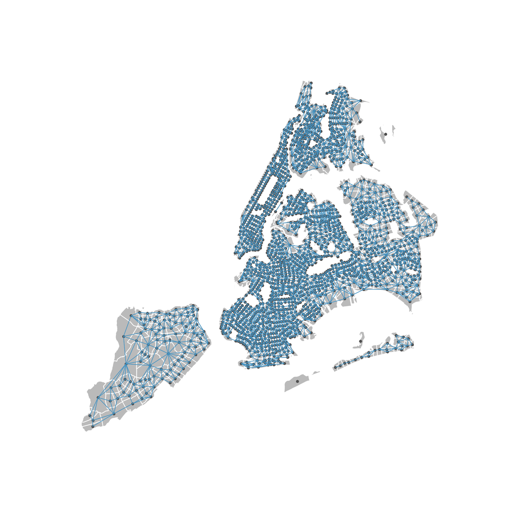

```python
clean_nbs_symmetric(nyc_nbs, manhattan_indices, brooklyn_and_queens)
plot_spatial_weights(nyc_nbs, nyc_geodata)
```

Further checks on the Python object require instantiating a new `W` object in order to recompute its attributes.

```python
nyc_nbs_clean = libpysal.weights.W(nyc_nbs.neighbors, nyc_nbs.weights)

print(f'is symmetric? {len(nyc_nbs_clean.asymmetries) == 0}')
print(f'number of components: {nyc_nbs_clean.n_components}')
unique, counts = np.unique(nyc_nbs_clean.component_labels, return_counts=True)
print('component ids ', unique, '\ncomponent size', counts)
```

```
is symmetric? True
number of components: 9
component ids  [0 1 2 3 4 5 6 7 8]
component size [ 329    1 1360  271    2    1   22    1  108]
```

** R **

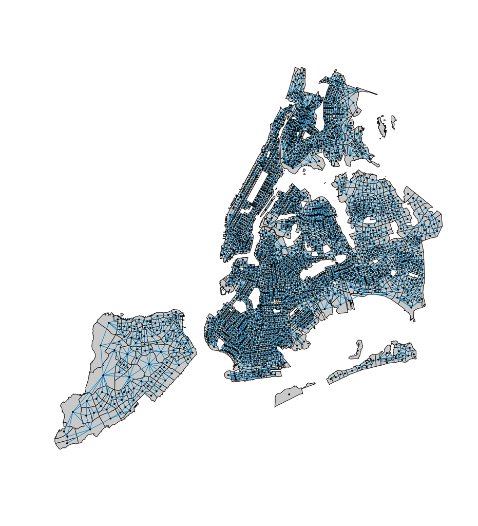

```r
nyc_nbs_cleaned <- clean_nbs_symmetric(nyc_nbs, manhattan_indices, brooklyn_and_queens)

plot(st_geometry(nyc_geodata), col='lightgrey')
plot(nyc_nbs_cleaned, coords=nyc_coords, col='deepskyblue3', add=TRUE, pch=20, cex=0.6)
```

```r
cat('is_symmetric? ', is.symmetric.nb(nyc_nbs_cleaned), '\n')
summary(nyc_nbs_cleaned)
cat('nodes per component')
table(n.comp.nb(nyc_nbs_cleaned)$comp.id)
```

```
is_symmetric?  TRUE
Neighbour list object:
Number of regions: 2095
Number of nonzero links: 10304
Percentage nonzero weights: 0.2347674
Average number of links: 4.918377
3 regions with no links:
329 1861 1904
9 disjoint connected subgraphs
Link number distribution:

  0   1   2   3   4   5   6   7   8   9  10  11  12
  3   7  34 226 549 653 396 148  55  10   8   4   2
7 least connected regions:
214 319 1311 1312 1329 1863 1974 with 1 link
2 most connected regions:
1023 1621 with 12 links
nodes per component
   1    2    3    4    5    6    7    8    9
 329    1 1360  271    2    1   22    1  108
```

## Adding edges to the neighbor graph

To add an edge between nodes `i` and `j` in the libpysal `W` object requires updating the `neighbors` and `weights` entries for both `i` and `j` as well as incrementing the cardinality of each. If this edit changes the component structure of the neighbor graph you must instantiate a new `W` object from the `neighbors` and `weights` list.

**Python**

```python
def add_symmetric_edge(w, i, j, weight=1.0):
    """
    Add a symmetric neighbor relationship between nodes i and j in a libpysal.weights.W object.

    Parameters:
    - w: libpysal.weights.W object
    - i: int or str, node identifier
    - j: int or str, node identifier
    - weight: float, weight to assign to the edge
    """
    if j not in w.neighbors[i]:
        w.neighbors[i].append(j)
        w.weights[i].append(weight)
        w.cardinalities[i] += 1
    if i not in w.neighbors[j]:
        w.neighbors[j].append(i)
        w.weights[j].append(weight)
        w.cardinalities[j] += 1
```

In R, the `nb` object’s lists are sorted by node index, ascending, therefore after appending the `i` and `j` node index to the `j` and `i` entries, the list is re-sorted. Singleton nodes must be handled separately - instead of an empty list, singleton nodes have a list with the entry 0, which is an invalid node index, therefore we replace this entry with the node index of the new edge.

**R**

```r
add_symmetric_edge_nb <- function(nb, i, j) {
  nb_res = nb
  if (!(j %in% nb[[i]])) {
    if (nb[[i]][1] == 0) {
      nb_res[[i]] = j
    } else {
      nb_res[[i]] <- sort(c(nb[[i]], j))
    }
  }
  if (!(i %in% nb[[j]])) {
    if (nb[[j]][1] == 0) {
      nb_res[[j]] = i
     } else {
       nb_res[[j]] <- sort(c(nb[[j]], i))
     }
  }
  return(nb_res)
}
```

### Example: New York City as single component

Going the other way, instead of removing connections between Manhattan and Brooklyn and Queens, we need to connect the other components and islands to the Manhattan / Brooklyn / Queens component. There are 4 additional components: the Bronx, Staten Island, the Rockaways, and Roosevelt Island, and three singleton nodes: City Island, Broad Channel, and Breezy Point.

Since the graph is not connected, there is no correct way to connect these regions, but we try to find reasonably “close” pairs of regions to connect.

** Python **

```python
# start from geodataframe
nyc_nbs = libpysal.weights.Rook.from_dataframe(nyc_geodata, geom_col='geometry')

add_symmetric_edge(nyc_nbs, 201, 1339) # Spuyten Duyvel to Inwood
add_symmetric_edge(nyc_nbs, 2010, 429) # Grasmere to Bay Ridge
add_symmetric_edge(nyc_nbs, 1311, 1190) # Roosevelt Island to Lenox Hill
add_symmetric_edge(nyc_nbs, 1310, 1385) # Roosevelt Island to Queensbridge
add_symmetric_edge(nyc_nbs, 328, 196) # City Island to Pelham Bay
add_symmetric_edge(nyc_nbs, 1860, 1862)  # Breezy Point to the Rockaways
add_symmetric_edge(nyc_nbs, 1860, 625)  # Breezy Point to Brighton Beach
add_symmetric_edge(nyc_nbs, 1870, 1903)  # Broad Channel to the Rockaways
add_symmetric_edge(nyc_nbs, 1903, 1858)  # Broad Channel to Howard Beech
```

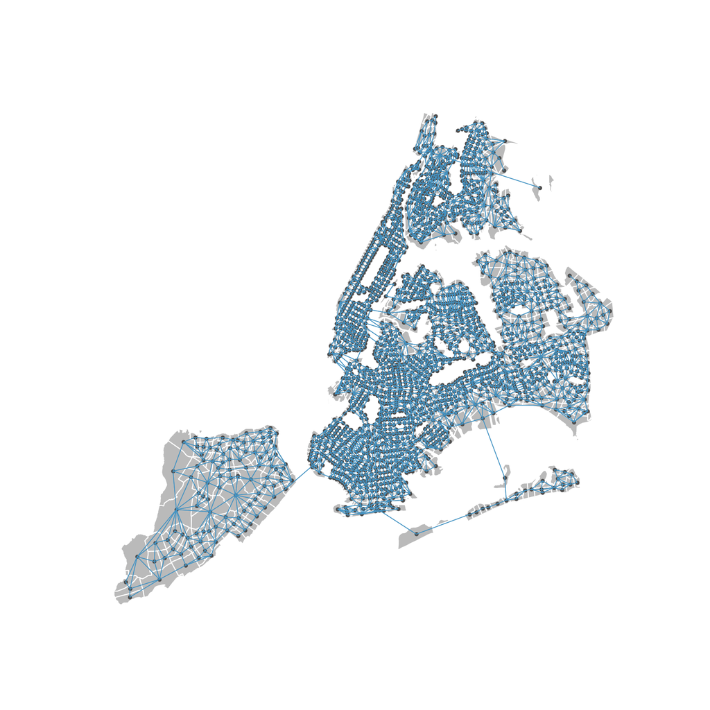

```python
# instantiate a new spatial weights object with the updated neighbors and weights
nyc_nbs_connected = libpysal.weights.W(nyc_nbs.neighbors, nyc_nbs.weights)
plot_spatial_weights(nyc_nbs_connected, nyc_geodata)
```

```python
# check your work
print(f'is symmetric? {len(nyc_nbs_connected.asymmetries) == 0}')
print(f'number of components: {nyc_nbs_connected.n_components}')
unique, counts = np.unique(nyc_nbs_connected.component_labels, return_counts=True)
print('component ids ', unique, '\ncomponent size', counts)
```

```
is symmetric? True
number of components: 1
component ids  [0]
component size [2095]
```

** R **

```r
# start from geodataframe
nyc_nbs = poly2nb(nyc_geodata, queen=FALSE)
```

Since R indexes from 1, we increment the indices accordingly.

```r
# R indexes from 1
nyc_nbs = add_symmetric_edge_nb(nyc_nbs, 202L, 1340L) # Spuyten Duyvel to Inwood
nyc_nbs = add_symmetric_edge_nb(nyc_nbs, 430L, 2011L) # Grasmere to Bay Ridge
nyc_nbs = add_symmetric_edge_nb(nyc_nbs, 1191L, 1312L) # Roosevelt Island to Lenox Hill
nyc_nbs = add_symmetric_edge_nb(nyc_nbs, 1311L, 1386L) # Roosevelt Island to Queensbridge
nyc_nbs = add_symmetric_edge_nb(nyc_nbs, 197L, 329L) # City Island to Pelham Bay
nyc_nbs = add_symmetric_edge_nb(nyc_nbs, 1861L, 1863L)  # Breezy Point to the Rockaways
nyc_nbs = add_symmetric_edge_nb(nyc_nbs, 626L, 1861L)  # Breezy Point to Brighton Beach
nyc_nbs = add_symmetric_edge_nb(nyc_nbs, 1871L, 1904L)  # Broad Channel to the Rockaways
nyc_nbs = add_symmetric_edge_nb(nyc_nbs, 1859L, 1904L)  # Broad Channel to Howard Beech
```

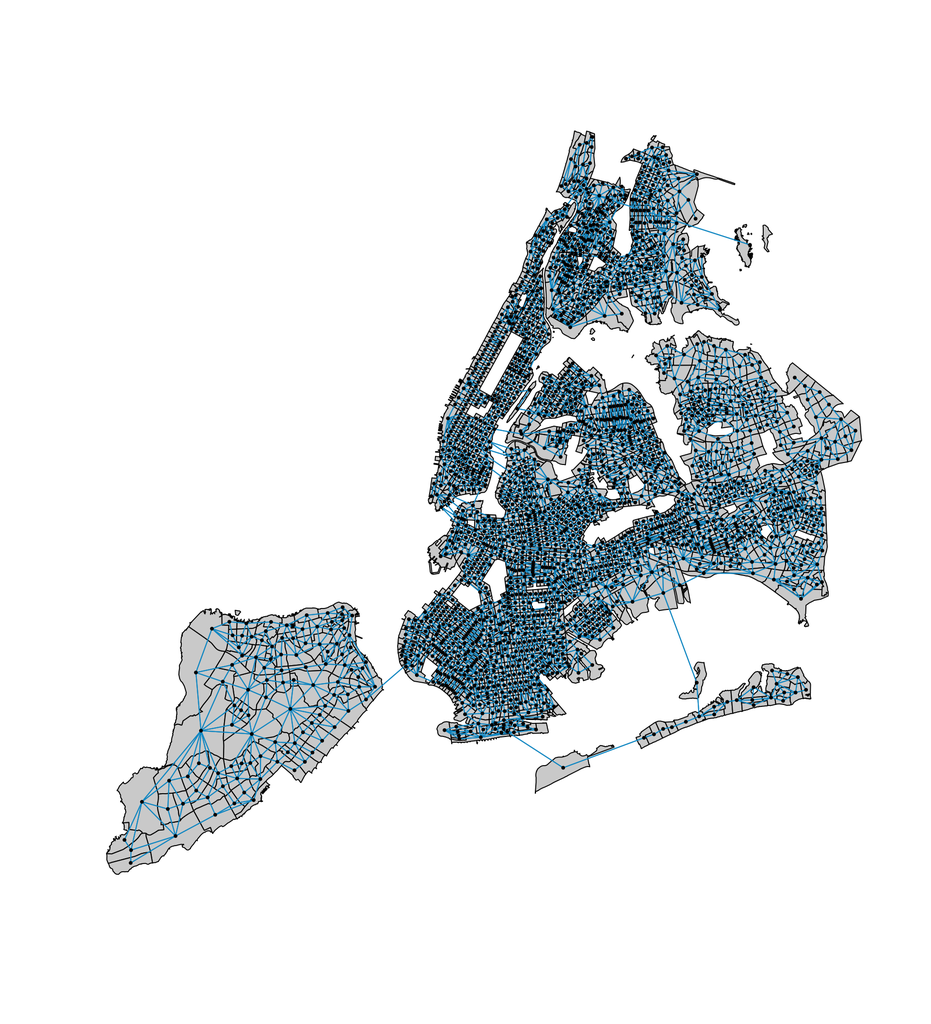

```r
plot(st_geometry(nyc_geodata), col='lightgrey')
plot(nyc_nbs, coords=nyc_coords, col='deepskyblue3', add=TRUE, pch=20, cex=0.6)
```

```r
# check your work
cat('is symmetric? ', is.symmetric.nb(nyc_nbs), '\n')
summary(nyc_nbs)
cat('nodes per component')
table(n.comp.nb(nyc_nbs)$comp.id)
```

```
is symmetric?  TRUE
Neighbour list object:
Number of regions: 2095
Number of nonzero links: 10346
Percentage nonzero weights: 0.2357243
Average number of links: 4.938425
Link number distribution:

  1   2   3   4   5   6   7   8   9  10  11  12
  5  38 214 552 657 399 150  56  10   8   4   2
5 least connected regions:
214 319 329 1329 1974 with 1 link
2 most connected regions:
1023 1621 with 12 links
nodes per component
   1
2095
```

## Comparison of packages `libpysal` and `spdep`

| **Aspect** | **`libpysal.weights.W` (Python)** | **`spdep::nb` (R)** |
| --- | --- | --- |
| **Data Structure** | Dictionaries (`neighbors`, `weights`, `cardinalities`) | List of integer vectors |
| **Adding Neighbors** | Append to lists and update weights/cardinalities | Insert into sorted vectors |
| **Disconnecting Neighbors** | Remove from `neighbors`, `weights`, and update `cardinalities` for both nodes | Remove from neighbor lists and maintain sorted order for both nodes |
| **Symmetry Handling** | Manually add or remove both directions | Manually add or remove both directions |
| **Weight Management** | Directly handled within the `W` object | Typically managed separately (e.g., `listw` objects) |
| **Sorted Neighbor Lists** | Not inherently sorted | Maintained in sorted order |

## Footnotes

[^1]: Computer science indexes from 0, and math (and statistics) index from 1. Stan also indexes from 1, unlike most programming languages.